# Mechanisms of Explosive Eruption and Fragmentation

Dr. Ahmad Redaa

19-10-2025

# Pyroclastic Terminology Overview

> Understanding pyroclastic terminology is essential for interpreting volcanic deposits and eruption mechanisms.
- Fall deposits
- Ignimbrites
- Surges
- Rock debris
- Pumice
- Volcanic ash

# Fall Deposits

**Definition:**  
- Products of **ash and lapilli** settling from an **eruption column or plume** through the atmosphere (air fall).  
- Form **bedded, well-sorted** layers that thin and fine away from the vent.

**Key Features:**  
- Graded bedding  
- Wide areal extent  
- Excellent stratigraphic markers (tephra layers)

**Examples:**  
- Plinian ash fall from Mount St. Helens (1980)  
- Campanian Ignimbrite fallout phase

# Ignimbrite

**Definition:**  
a rock formed from the deposits of a pyroclastic flow, a fast-moving, hot avalanche of volcanic gas and ash.

**Key Textures:**  
- **Eutaxitic texture** (flattened pumice = fiamme)  
- Massive or stratified flow units  
- May contain lithic fragments and crystals

# Pyroclastic Surge

**Definition:**  
a fast-moving, ground-hugging, turbulent cloud of hot volcanic gas and rock fragments that can be extremely destructive.

**Features:**  
- Cross-bedding, dune forms, erosive bases  
- Finer grain size and better sorting than ignimbrites  
- Common in tuff rings and maars

# Rock Debris (Lithic Fragments)

**Definition:**  
- **Pre-existing country-rock fragments** or older volcanic materials entrained during eruption.  
- May be derived from conduit walls, crater floors, or older deposits.

**Indicators:**  
- Angular, dense, crystalline fragments  
- Lack vesicles or glassy textures  
- Often hydrothermally altered (especially in phreatic eruptions)

**Significance:**  
Helps identify vent erosion and eruption type (juvenile vs. accidental material).

# Pumice

**Definition:**  
- **Highly vesicular volcanic glass** formed by expansion of gas-rich silicic magma during explosive eruption.  
- Very low density — often floats on water.

**Textures:**  
- Frothy, fibrous vesicular structure  
- Can deform plastically during welding (forms *fiamme*)

**Occurs in:**  
- Rhyolitic to dacitic ignimbrites and fall deposits

# Volcanic Ash

**Definition:**  
- **Pyroclastic particles < 2 mm** in diameter produced by magma fragmentation or rock shattering.  
- May consist of glass shards, crystals, or lithic fragments.

**Deposition:**  
- Air-fall (plumes) or ground-hugging surges/flows  
- Often forms fine, laminated tuff layers

**Importance:**  
- Excellent for tephrochronology  
- Reflects eruption intensity and fragmentation efficiency

# What Makes an Eruption Explosive?

Explosive eruptions result from the **rapid expansion of gases** within magma.  
As magma ascends and pressure decreases, **dissolved volatiles** (H₂O, CO₂, SO₂) exsolve to form bubbles.

If bubbles cannot escape, pressure builds until magma **fragments violently**, forming **ash, pumice, and pyroclasts**.

| Factor | Effect on Explosivity |
| --- | --- |
| Volatile content | More gas = higher explosivity |
| Viscosity | High viscosity traps gases → explosive |
| Ascent rate | Rapid decompression promotes fragmentation |
| External water | Enhances explosivity (steam expansion) |

# Magmatic Fragmentation (Eruption)

**Occurs within the magma itself** due to gas overpressure.

**Stages:**  
1. Bubble nucleation  
2. Bubble growth & coalescence  
3. Overpressure buildup  
4. Fragmentation (rupture)

**Products:**  
- Pumice (silicic magma)  
- Scoria (mafic magma)  
- Volcanic ash

**Controls:**  
- Viscosity (rhyolitic > basaltic)  
- Gas content (2–6 wt% H₂O)  
- Fragmentation threshold (~1–10 MPa)

# Phreatomagmatic Fragmentation

**Magma + external water → violent vaporization**

1. Magma–water contact
2. Flashing of water to steam
3. Explosive pressure pulses
4. Thermal shock fragmentation

**Products:**  
- Fine ash, tuff rings  
- Angular glassy clasts  
- Accretionary lapilli

**Example:** *Surtsey, Iceland (1963)*

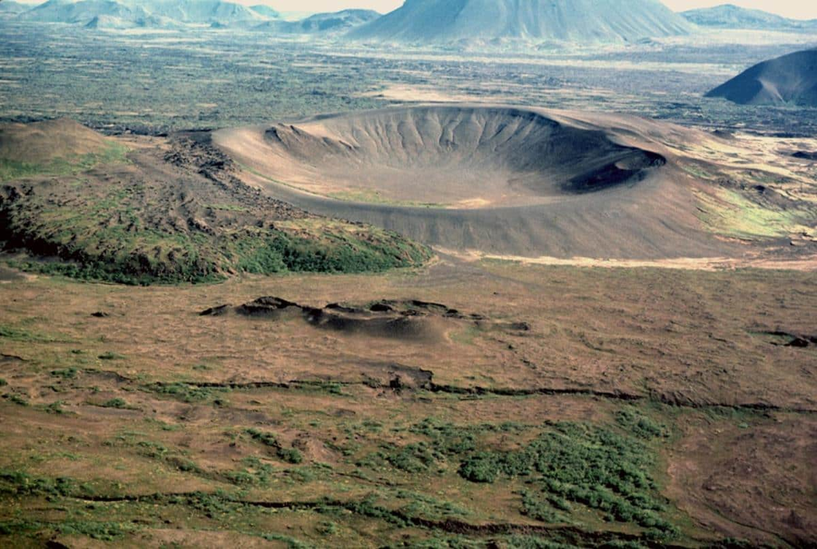

Source: geologybase.com/tuff-rings/

# Phreatic Fragmentation

- Caused by **heating of external water**, *no new magma involved*
- Steam expansion fragments pre-existing rock

**Products:**  
- Non-juvenile fragments  
- Hydrothermal vent breccias

**Example:** *Mount Ontake, Japan (2014)*

# Phreatomagmatic vs. Phreatic Fragmentation

| Feature | **Phreatomagmatic Fragmentation** | **Phreatic Fragmentation** |
| --- | --- | --- |
| **Definition** | Magma interacts directly with external water, causing violent vaporization and fragmentation of magma. | Steam explosion caused by heating of water by hot rock or gases — *no new magma involved*. |
| **Magma Involvement** | Magma fragments → juvenile pyroclasts. | No magma fragmentation → only pre-existing rock ejected. |
| **Driving Mechanism** | Thermal shock and rapid steam expansion from magma–water contact. | Steam overpressure from heated groundwater. |
| **Products** | Fine ash, glassy shards, tuff rings, base surges, accretionary lapilli. | Lithic fragments, hydrothermal breccias, altered rock debris. |
| **Deposit Characteristics** | Well-sorted, blocky ash; common in maars and tuff cones. | Poorly sorted breccia; hydrothermally altered vent zones. |
| **Examples** | Surtsey (Iceland 1963), Taal (Philippines). | Mount Ontake (Japan 2014), White Island (New Zealand). |
| **Hazard Style** | Sustained, ash-rich eruptions with base surges. | Sudden, short-lived explosions with little warning. |

# Fragmentation Mechanisms Summary

| Mechanism | Products | Typical Deposits | Example |
| --- | --- | --- | --- |
| Magmatic | Pumice, ash | Fall, ignimbrite | Mount St. Helens 1980 |
| Phreatomagmatic | Fine ash, glass shards | Tuff ring, surge | Surtsey 1963 |
| Phreatic | Rock debris | Hydrothermal breccia | Ontake 2014 |